# bettybuilds - Portfolio website

- Home
- Projects
- About me

## Projects

[figure not shown]

### Cyclistic - The bike sharing company

A Google case study analysis using mySQL for merging historical data, then using Python to clean and manipulate data finishing with fact-finding visualization.

### Summary

- Launch in 2016
- The program has grown to a fleet of 5,524 bicycles
- Geotracked and locked into a network of 692 stations across Chicago
- Marketing strategy was to build general awereness to a broad consumer segment
- Pricing plan has two options:
  - casual riders: single-ride or full-day passes
  - annual membership

Although the pricing flexibility helps Cyclistic attract more customers, the team believes that **maximizing the number of annual members will be the key to future growth**. Rather than creating a marketing campaign that targets all-new customers, there might be a very good chance to convert casual riders into members. The problem is that **the casual riders** are already aware of the services and **have already chosen Cyclistic for their mobility needs**.

### The business task

> *Key stakeholders: Lily Moreno (The director of marketing and the manager), Cyclistic marketing analytics team and the Cyclistic executive team*

Clear goal is to design marketing strategies aimed at converting casual riders into annual members. In order to do that, however, the marketing analyst team needs to **better understand how annual members and casual riders differ, why casual riders would buy a membership, and how digital media could affect their marketing tactics**.

There are three questions that will guide the future marketing program:

1. How do annual members and casual riders use Cyclistic bikes differently?
2. Why would casual riders buy Cyclistic annual memberships?
3. How can Cyclistic use digital media to influence casual riders to become members?

My scope would be to analyze the first question with the previous 12 months of **[Cyclistic historical bike trip data](https://divvy-tripdata.s3.amazonaws.com/index.html)** to identify trends.

### **** Disclaimer ****

> Cyclisist is a fictional company. For the sole purpose of this case study the historical dataset is appropriate and can be used to answer the business questions. Nevertheless, the owner of the dataset is Motivate International Inc. under **[this licence.](https://ride.divvybikes.com/data-license-agreement)** Motivate International Inc. disclaims any warranty that data will meet your needs or will be or continue to be available, complete, accurate, timely, secure or error free.

### The data

This dataset is ROCCC:

- Reliable, Original and Cited: complete time series, which are accurate for the task and is non-bias. We will treat them as second-party datasets from a reliable organization.
- Current and Comprehensive: we consider them as regularly refreshed datasets, which are appropriate and will enable us to answer the business questions.

Data has been downloaded and stored locally and uploaded into Google Drive as a back-up.

I wasn't able to choose the quarterly files, because the latest was back in 2020, so I downloaded the monthly versions in csv from March of 2022 until February 2023.

These files are structured and organized in 13 columns without indicies including quantitative and qualitative data.

I'm using **[MySQL to combine data into one file](https://github.com/bettybuilds/Cyclistic)** from multiple csv files. Then I'm going to use MySQL connector to bring the data into Python to clean, manipulate and analyze the data with some detailed visualizations.

```python
import mysql.connector
			import csv
			import sys

			db = mysql.connector.connect(
			  host='localhost',
			  user='root',
			  password='*********',
			  database='cyclistic'
			)

			cursor = db.cursor()

			query = 'SELECT * FROM data'

			csv_path = 'C:/Users/Betti/Desktop/case study/historical data/alldata.csv'

			try:
				cursor.execute(query)
				rows = cursor.fetchall()
			finally:
				db.close()

			# Continue only if there are rows returned.
			if rows:
				# New empty list called 'result'. This will be written to a file.
				result = list()

				# The row name is the first entry for each entity in the description tuple.
				column_names = list()
				for i in cursor.description:
					column_names.append(i[0])

				result.append(column_names)
				for row in rows:
					result.append(row)

				# Write result to file.
				with open(csv_path, 'w', newline='') as csvfile:
					csvwriter = csv.writer(csvfile, delimiter=',', quotechar='"', quoting=csv.QUOTE_MINIMAL)
					for row in result:
						csvwriter.writerow(row)
			else:
				sys.exit("No rows found for query: {}".format(query))
```

## Exploratory data analysis and data cleaning

```python
import pandas as pd
			df = pd.read_csv('alldata.csv')
```

```python
df.shape
```

```
(5829084, 13)
```

```python
df.index
```

```
RangeIndex(start=0, stop=5829084, step=1)
```

```python
df.info()
```

```
<class 'pandas.core.frame.DataFrame'>
			RangeIndex: 5829084 entries, 0 to 5829083
			Data columns (total 13 columns):
			 #   Column              Dtype
			---  ------              -----
			 0   ride_id             object
			 1   rideable_type       object
			 2   started_at          object
			 3   ended_at            object
			 4   start_station_name  object
			 5   start_station_id    object
			 6   end_station_name    object
			 7   end_station_id      object
			 8   start_lat           float64
			 9   start_lng           float64
			 10  end_lat             float64
			 11  end_lng             float64
			 12  member_casual       object
			dtypes: float64(4), object(9)
			memory usage: 578.1+ MB
```

```python
df.head()
```

|  | ride_id | rideable_type | started_at | ended_at | start_station_name | start_station_id | end_station_name | end_station_id | start_lat | start_lng | end_lat | end_lng | member_casual |
| --- | --- | --- | --- | --- | --- | --- | --- | --- | --- | --- | --- | --- | --- |
| 0 | 47EC0A7F82E65D52 | classic_bike | 2022-03-21 13:45:01 | 2022-03-21 13:51:18 | Wabash Ave & Wacker Pl | TA1307000131 | Kingsbury St & Kinzie St | KA1503000043 | 41.8869 | -87.6260 | 41.8892 | -87.6385 | member |
| 1 | 8494861979B0F477 | electric_bike | 2022-03-16 09:37:16 | 2022-03-16 09:43:34 | Michigan Ave & Oak St | 13042 | Orleans St & Chestnut St (NEXT Apts) | 620 | 41.9010 | -87.6237 | 41.8982 | -87.6375 | member |
| 2 | EFE527AF80B66109 | classic_bike | 2022-03-23 19:52:02 | 2022-03-23 19:54:48 | Broadway & Berwyn Ave | 13109 | Broadway & Ridge Ave | 15578 | 41.9784 | -87.6598 | 41.9840 | -87.6603 | member |
| 3 | 9F446FD9DEE3F389 | classic_bike | 2022-03-01 19:12:26 | 2022-03-01 19:22:14 | Wabash Ave & Wacker Pl | TA1307000131 | Franklin St & Jackson Blvd | TA1305000025 | 41.8869 | -87.6260 | 41.8777 | -87.6353 | member |
| 4 | 431128AD9AFFEDC0 | classic_bike | 2022-03-21 18:37:01 | 2022-03-21 19:19:11 | DuSable Lake Shore Dr & North Blvd | LF-005 | Loomis St & Jackson Blvd | 13206 | 41.9117 | -87.6268 | 41.8779 | -87.6620 | member |

- **ride_id:** unique identifier for each rides
- **rideable_type:** type of the bike (classic, docked and electric)
- **started_at:** datetime object for stamping the start time of the ride (%Y-%m-%d %H:%M:%S)
- **ended_at:** datetime object for stamping the end time of the ride (%Y-%m-%d %H:%M:%S)
- **start_station_name:** the name of the starting station (location)
- **start_station_id:** the ID of the starting station
- **end_station_name:** the name of the ending station (location)
- **end_station_id:** the ID of the ending station
- **start_lat:** the latitude of the starting station
- **start_lng:** the longitude of the starting station
- **end_lat:** the latitude of the ending station
- **end_lng:** the longtitude of the ending station
- **member_casual:** the customer type (casual rider or annual member)

```python
# For this analysis I don't need the geographical data.

			df = df.drop(columns=[
				'start_station_name', 'start_station_id',
				'end_station_name', 'end_station_id',
				'start_lat', 'start_lng',
				'end_lat', 'end_lng'])
```

```python
# Converting datetime data into the correct format.

			df['started_at'] = pd.to_datetime(df['started_at'], format='%Y-%m-%d %H:%M:%S')
			df['ended_at'] = pd.to_datetime(df['ended_at'], format='%Y-%m-%d %H:%M:%S')
			df.head()
```

|  | ride_id | rideable_type | started_at | ended_at | member_casual |
| --- | --- | --- | --- | --- | --- |
| 0 | 47EC0A7F82E65D52 | classic_bike | 2022-03-21 13:45:01 | 2022-03-21 13:51:18 | member |
| 1 | 8494861979B0F477 | electric_bike | 2022-03-16 09:37:16 | 2022-03-16 09:43:34 | member |
| 2 | EFE527AF80B66109 | classic_bike | 2022-03-23 19:52:02 | 2022-03-23 19:54:48 | member |
| 3 | 9F446FD9DEE3F389 | classic_bike | 2022-03-01 19:12:26 | 2022-03-01 19:22:14 | member |
| 4 | 431128AD9AFFEDC0 | classic_bike | 2022-03-21 18:37:01 | 2022-03-21 19:19:11 | member |

```python
# Adding period (%Y-%m) and the day of the week.

			df['period'] = pd.to_datetime(df['started_at']).dt.to_period('M')
			df['day_of_week'] = pd.to_datetime(df['started_at']).dt.day_name()
			df.head()
```

|  | ride_id | rideable_type | started_at | ended_at | member_casual | period | day_of_week |
| --- | --- | --- | --- | --- | --- | --- | --- |
| 0 | 47EC0A7F82E65D52 | classic_bike | 2022-03-21 13:45:01 | 2022-03-21 13:51:18 | member | 2022-03 | Monday |
| 1 | 8494861979B0F477 | electric_bike | 2022-03-16 09:37:16 | 2022-03-16 09:43:34 | member | 2022-03 | Wednesday |
| 2 | EFE527AF80B66109 | classic_bike | 2022-03-23 19:52:02 | 2022-03-23 19:54:48 | member | 2022-03 | Wednesday |
| 3 | 9F446FD9DEE3F389 | classic_bike | 2022-03-01 19:12:26 | 2022-03-01 19:22:14 | member | 2022-03 | Tuesday |
| 4 | 431128AD9AFFEDC0 | classic_bike | 2022-03-21 18:37:01 | 2022-03-21 19:19:11 | member | 2022-03 | Monday |

```python
# Adding the duration of the rides.

			df['ride_length'] = (df['ended_at'] - df['started_at']) / pd.Timedelta(minutes=1)
			df.head()
```

|  | ride_id | rideable_type | started_at | ended_at | member_casual | period | day_of_week | ride_length |
| --- | --- | --- | --- | --- | --- | --- | --- | --- |
| 0 | 47EC0A7F82E65D52 | classic_bike | 2022-03-21 13:45:01 | 2022-03-21 13:51:18 | member | 2022-03 | Monday | 6.283333 |
| 1 | 8494861979B0F477 | electric_bike | 2022-03-16 09:37:16 | 2022-03-16 09:43:34 | member | 2022-03 | Wednesday | 6.300000 |
| 2 | EFE527AF80B66109 | classic_bike | 2022-03-23 19:52:02 | 2022-03-23 19:54:48 | member | 2022-03 | Wednesday | 2.766667 |
| 3 | 9F446FD9DEE3F389 | classic_bike | 2022-03-01 19:12:26 | 2022-03-01 19:22:14 | member | 2022-03 | Tuesday | 9.800000 |
| 4 | 431128AD9AFFEDC0 | classic_bike | 2022-03-21 18:37:01 | 2022-03-21 19:19:11 | member | 2022-03 | Monday | 42.166667 |

```python
# Checking for white spaces in non-numerical data.

			df['ride_id'].str.isspace().value_counts()
```

```
False    5829084
			Name: ride_id, dtype: int64
```

```python
df['rideable_type'].str.isspace().value_counts()
```

```
False    5829084
			Name: rideable_type, dtype: int64
```

```python
df['member_casual'].str.isspace().value_counts()
```

```
False    5829084
			Name: member_casual, dtype: int64
```

#### Now that we have a good base file, we can check for data consistency.

```python
df.isna().sum()

			# DataFrame doesn't containing any missing values.
```

```
ride_id          0
			rideable_type    0
			started_at       0
			ended_at         0
			member_casual    0
			period           0
			day_of_week      0
			ride_length      0
			dtype: int64
```

```python
# Since ride_id is a unique identifier, let's check if it has any duplication.

			df[df['ride_id'].duplicated()]
```

|  | ride_id | rideable_type | started_at | ended_at | member_casual | period | day_of_week | ride_length |
| --- | --- | --- | --- | --- | --- | --- | --- | --- |

```python
df.info()
```

```
<class 'pandas.core.frame.DataFrame'>
			RangeIndex: 5829084 entries, 0 to 5829083
			Data columns (total 8 columns):
			 #   Column         Dtype
			---  ------         -----
			 0   ride_id        object
			 1   rideable_type  object
			 2   started_at     datetime64[ns]
			 3   ended_at       datetime64[ns]
			 4   member_casual  object
			 5   period         period[M]
			 6   day_of_week    object
			 7   ride_length    float64
			dtypes: datetime64[ns](2), float64(1), object(4), period[M](1)
			memory usage: 355.8+ MB
```

```python
# We can check if there is any interesting statistical data in our dataset including the non-numerical data as well.

			df.describe(include=object)
```

|  | ride_id | rideable_type | member_casual | day_of_week |
| --- | --- | --- | --- | --- |
| count | 5829084 | 5829084 | 5829084 | 5829084 |
| unique | 5829084 | 3 | 4 | 7 |
| top | 47EC0A7F82E65D52 | electric_bike | member | Saturday |
| freq | 1 | 2983084 | 3059323 | 933297 |

- The row count for all columns are correct.
- As we just checked the unique identifier (ride_id) is equal to the row count, so that's correct as well.

```python
df['rideable_type'].value_counts()
```

```
electric_bike    2983084
			classic_bike     2666915
			docked_bike       179085
			Name: rideable_type, dtype: int64
```

- We have three types of bikes:
  - electric bike
  - classic bike
  - docked bike

```python
df['member_casual'].value_counts()
```

```
member     3059323
			casual     2068424
			member;     404641
			casual;     296696
			Name: member_casual, dtype: int64
```

- I have noticed that there is a problem with the member_casual column, as some of them has a ; symbol at the end.

```python
df['member_casual'] = df['member_casual'].str.replace(';','')
			df['member_casual'].value_counts()
```

```
member    3463964
			casual    2365120
			Name: member_casual, dtype: int64
```

```python
# I find the member_casual column name a bit confusing, so let's rename it!

			df.columns = df.columns.str.replace('member_casual', 'customer_type')
			df.head()
```

|  | ride_id | rideable_type | started_at | ended_at | customer_type | period | day_of_week | ride_length |
| --- | --- | --- | --- | --- | --- | --- | --- | --- |
| 0 | 47EC0A7F82E65D52 | classic_bike | 2022-03-21 13:45:01 | 2022-03-21 13:51:18 | member | 2022-03 | Monday | 6.283333 |
| 1 | 8494861979B0F477 | electric_bike | 2022-03-16 09:37:16 | 2022-03-16 09:43:34 | member | 2022-03 | Wednesday | 6.300000 |
| 2 | EFE527AF80B66109 | classic_bike | 2022-03-23 19:52:02 | 2022-03-23 19:54:48 | member | 2022-03 | Wednesday | 2.766667 |
| 3 | 9F446FD9DEE3F389 | classic_bike | 2022-03-01 19:12:26 | 2022-03-01 19:22:14 | member | 2022-03 | Tuesday | 9.800000 |
| 4 | 431128AD9AFFEDC0 | classic_bike | 2022-03-21 18:37:01 | 2022-03-21 19:19:11 | member | 2022-03 | Monday | 42.166667 |

```python
df.describe(include=object)

			# Now the big picture looks logical.
```

|  | ride_id | rideable_type | customer_type | day_of_week |
| --- | --- | --- | --- | --- |
| count | 5829084 | 5829084 | 5829084 | 5829084 |
| unique | 5829084 | 3 | 2 | 7 |
| top | 47EC0A7F82E65D52 | electric_bike | member | Saturday |
| freq | 1 | 2983084 | 3463964 | 933297 |

```python
# How does it look if we only check the numerical data, which is the ride_length?

			df.describe()
```

|  | ride_length |
| --- | --- |
| count | 5.829084e+06 |
| mean | 1.921743e+01 |
| std | 1.751585e+02 |
| min | -1.035335e+04 |
| 25% | 5.733333e+00 |
| 50% | 1.015000e+01 |
| 75% | 1.823333e+01 |
| max | 4.138725e+04 |

Something is not right! It's not possible to have a negative value when checking the minimum of the ride_length.

```python
df[df['ride_length'] < 0].count()

			# We have 101 rows which contains negative value.
```

```
ride_id          101
			rideable_type    101
			started_at       101
			ended_at         101
			customer_type    101
			period           101
			day_of_week      101
			ride_length      101
			dtype: int64
```

```python
df[df['ride_length'] < 0]

			# It seems like these are faulty registries as the start date happens later than the end date.
```

|  | ride_id | rideable_type | started_at | ended_at | customer_type | period | day_of_week | ride_length |
| --- | --- | --- | --- | --- | --- | --- | --- | --- |
| 184212 | 2D97E3C98E165D80 | classic_bike | 2022-03-05 11:00:57 | 2022-03-05 10:55:01 | casual | 2022-03 | Saturday | -5.933333 |
| 187389 | 7407049C5D89A13D | electric_bike | 2022-03-05 11:38:04 | 2022-03-05 11:37:57 | casual | 2022-03 | Saturday | -0.116667 |
| 1247676 | 0793C9208A64302A | electric_bike | 2022-05-30 11:06:29 | 2022-05-30 11:06:17 | casual | 2022-05 | Monday | -0.200000 |
| 1416258 | B897BE02B21FA75E | electric_bike | 2022-06-07 19:15:39 | 2022-06-07 17:05:37 | casual | 2022-06 | Tuesday | -130.033333 |
| 1416681 | 072E947E156D142D | electric_bike | 2022-06-07 19:14:46 | 2022-06-07 17:07:45 | casual | 2022-06 | Tuesday | -127.016667 |
| ... | ... | ... | ... | ... | ... | ... | ... | ... |
| 5223673 | 75780B25C9DF4DB1 | electric_bike | 2022-11-06 01:59:42 | 2022-11-06 01:04:20 | member | 2022-11 | Sunday | -55.366667 |
| 5244909 | 4139B11634039661 | classic_bike | 2022-11-06 01:58:46 | 2022-11-06 01:11:33 | member | 2022-11 | Sunday | -47.216667 |
| 5259066 | 1BA8DEBE4E13DD1D | electric_bike | 2022-11-06 01:52:09 | 2022-11-06 01:04:23 | casual | 2022-11 | Sunday | -47.766667 |
| 5259206 | FB90B13B85686836 | electric_bike | 2022-11-06 01:51:26 | 2022-11-06 01:13:46 | member | 2022-11 | Sunday | -37.666667 |
| 5827986 | 4EFC95304E050AA1 | electric_bike | 2023-02-04 13:08:08 | 2023-02-04 13:04:52 | member | 2023-02 | Saturday | -3.266667 |

101 rows × 8 columns

```python
error_percentage = (101 / len(df['ride_id']))*100

			error_percentage
```

```
0.0017326907623907977
```

Since this error only occurs in 0.0017% of the cases, I'm going to delete these rows. This cleaning won't cause significant difference in the analysis, however it's safer to eliminate such bugs.

```python
# If we have negative amounts, do we have any under a minute?

			df[df['ride_length'] <= 1].count()
```

```
ride_id          130133
			rideable_type    130133
			started_at       130133
			ended_at         130133
			customer_type    130133
			period           130133
			day_of_week      130133
			ride_length      130133
			dtype: int64
```

```python
error_percentage2 = (130133 / len(df['ride_id']))*100

			error_percentage2
```

```
2.232477692893086
```

I could go ahead and only delete the negative values, but I'll use a 1 minute limit instead. This method will eliminate the cases when the customers were probably incorrectly docking, opening a new ride_id.

```python
df = df[df['ride_length'] >= 1]
			df.shape
```

```
(5700215, 8)
```

```python
df = df.reset_index()
			df = df.drop(columns=['index'])
```

```python
df.head()
```

|  | ride_id | rideable_type | started_at | ended_at | customer_type | period | day_of_week | ride_length |
| --- | --- | --- | --- | --- | --- | --- | --- | --- |
| 0 | 47EC0A7F82E65D52 | classic_bike | 2022-03-21 13:45:01 | 2022-03-21 13:51:18 | member | 2022-03 | Monday | 6.283333 |
| 1 | 8494861979B0F477 | electric_bike | 2022-03-16 09:37:16 | 2022-03-16 09:43:34 | member | 2022-03 | Wednesday | 6.300000 |
| 2 | EFE527AF80B66109 | classic_bike | 2022-03-23 19:52:02 | 2022-03-23 19:54:48 | member | 2022-03 | Wednesday | 2.766667 |
| 3 | 9F446FD9DEE3F389 | classic_bike | 2022-03-01 19:12:26 | 2022-03-01 19:22:14 | member | 2022-03 | Tuesday | 9.800000 |
| 4 | 431128AD9AFFEDC0 | classic_bike | 2022-03-21 18:37:01 | 2022-03-21 19:19:11 | member | 2022-03 | Monday | 42.166667 |

## The analysis

```python
import numpy as np
			import matplotlib.pyplot as plt
			import seaborn as sns
```

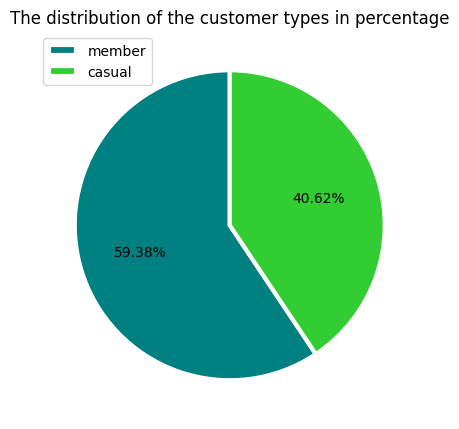

```python
# Count the number of each customer type
			num_of_customer_type = df['customer_type'].value_counts()

			plt.figure(figsize = (5,6))

			plt.pie(num_of_customer_type.values,
			autopct= '%1.2f%%',
			startangle = 90,
			wedgeprops = { 'linewidth' : 3, 'edgecolor' : 'white' },
			colors = {'teal', 'limegreen'})


			plt.legend(num_of_customer_type.index)
			plt.show
			plt.title('The distribution of the customer types in percentage')
```

```python
# Same numbers in a pivot table

			num_of_customer_type_pivot = pd.pivot_table(df,
						  index = 'customer_type',
						  values = 'ride_id',
						  aggfunc = 'count',
						  margins = True,
						  margins_name = 'Total number of rides')

			num_of_customer_type_pivot
```

| customer_type | ride_id |
| --- | --- |
| casual | 2315662 |
| member | 3384553 |
| Total number of rides | 5700215 |

We are already on a good page with this pie chart, because it shows that the most profitable customer type has the largest distribution of the customers. Our job will be to further analyze the data and find triggers that could increase this percentage.

```python
mean_ride_length_pivot = (pd.pivot_table(df,
								index = 'customer_type',
								values = 'ride_length',
								aggfunc = 'mean')
					.add_prefix('The average minute of the '))

			mean_ride_length_pivot
```

| customer_type | The average minute of the ride_length |
| --- | --- |
| casual | 29.553086 |
| member | 12.865948 |

Casual riders are using the bikes longer than the annual members by ~17 minutes.

```python
mean_ride_length_per_day_pivot = pd.pivot_table(df,
								index = 'customer_type',
								columns = 'day_of_week',
								values = 'ride_length',
								aggfunc= 'mean',
								margins=True, margins_name='Total average in minutes')

			mean_ride_length_per_day_pivot
```

| day_of_week customer_type | Friday | Monday | Saturday | Sunday | Thursday | Tuesday | Wednesday | Total average in minutes |
| --- | --- | --- | --- | --- | --- | --- | --- | --- |
| casual | 28.481494 | 29.507847 | 33.257413 | 34.632785 | 25.808689 | 26.078184 | 24.908466 | 29.553086 |
| member | 12.682452 | 12.425239 | 14.381967 | 14.269299 | 12.433479 | 12.193925 | 12.230083 | 12.865948 |
| Total average in minutes | 19.218316 | 18.702853 | 24.073902 | 24.413468 | 17.312818 | 16.813421 | 16.549590 | 19.644950 |

```python
avg_ride_length_for_casuals = (
				df[df['customer_type'] == 'casual']
				.groupby('day_of_week')['ride_length']
				.mean()
				.sort_values(ascending = False)
				)

			avg_ride_length_for_casuals
```

```
day_of_week
			Sunday       34.632785
			Saturday     33.257413
			Monday       29.507847
			Friday       28.481494
			Tuesday      26.078184
			Thursday     25.808689
			Wednesday    24.908466
			Name: ride_length, dtype: float64
```

```python
avg_ride_length_for_members = (
				df[df['customer_type'] == 'member']
				.groupby('day_of_week')['ride_length']
				.mean()
				.sort_values(ascending=False)
				)

			avg_ride_length_for_members
```

```
day_of_week
			Saturday     14.381967
			Sunday       14.269299
			Friday       12.682452
			Thursday     12.433479
			Monday       12.425239
			Wednesday    12.230083
			Tuesday      12.193925
			Name: ride_length, dtype: float64
```

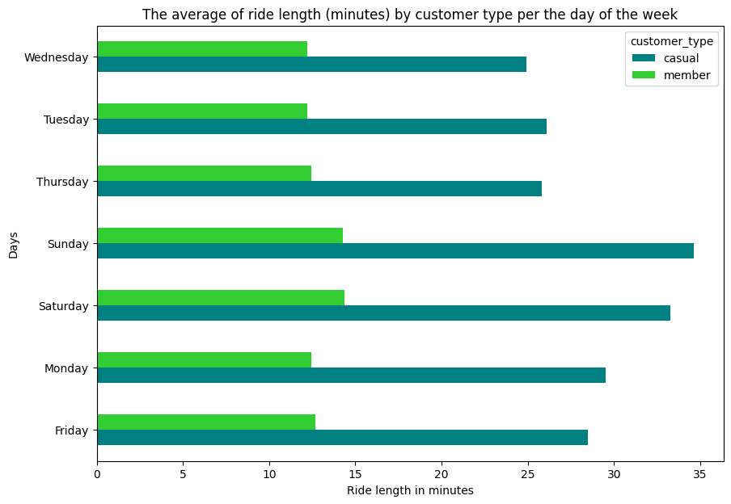

```python
np.round(pd.pivot_table(df, values = 'ride_length',
											index = 'day_of_week',
											columns = 'customer_type',
											aggfunc = 'mean',
											fill_value = 0), 2).plot.barh(
												figsize=  (10,7),
												color = {'member': 'limegreen', 'casual': 'teal'},
												title = 'The average of ride length (minutes) by customer type per the day of the week')

			plt.xlabel('Ride length in minutes')
			plt.ylabel('Days')
```

It looks like the annual members are riding for the same amount of time on the weekdays. This fact suggests that these customers have **bought annual membership because they use the bikes for the same purpose each day - not like the casual riders**. The lenght of the rides are increasing on weekends.

Clearly there is an increase with the casual riders as well on the weekends. At this time I'm not able to identify any other trend.

> If there would be customer IDs, we could investigate what is the growth in usage on the weekends with the annual members. Would be interesting to check what causes the longer rides, for example if it's registered by the same customers. We may have annual members who are only riding for the weekends doing the same trips over and over again.

Nevertheless, we can check the distribution of the ride IDs per customer type which could give us some insight on this topic.

```
[Text(0.5, 1.0, 'Weekly distribution of the number of rides by casual riders')]
```

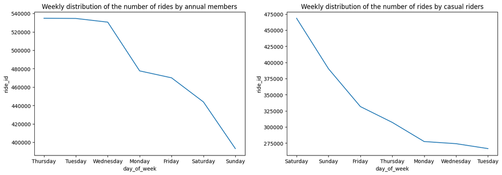

```python
fig, axes = plt.subplots(nrows=1, ncols=2, figsize=(16, 5))

			# Creating new DataFrame for subplots by customer type per week using the count of the unique identifier checking the mean of the ride lengths:
			df1 = df.loc[df['customer_type'] == 'member'] \
				.groupby(['day_of_week'], as_index=False) \
				.agg({'ride_id': 'count', 'ride_length': 'mean'}) \
				.sort_values('ride_id', ascending=False)

			sns.lineplot(ax=axes[0],
			x = df1['day_of_week'],
			y = df1['ride_id']) \
			.set(title = 'Weekly distribution of the number of rides by annual members')

			df2 = df.loc[df['customer_type'] == 'casual'] \
				.groupby(['day_of_week'], as_index=False) \
				.agg({'ride_id': 'count', 'ride_length': 'mean'}) \
				.sort_values('ride_id', ascending=False)

			sns.lineplot(ax=axes[1],
			x = df2['day_of_week'],
			y = df2['ride_id']) \
			.set(title = 'Weekly distribution of the number of rides by casual riders')
```

If we check the weekly usage (the number of rides), we can see a fascinating difference between the two customer types: **the busiest for the annual members are the weekdays, and the casual riders tend to ride more on the weekends.** This leads to the conclusion that the annual members are probably ride to and from work or running the same errands.

I see that the annual members are using the service less on Mondays and Fridays. This is probably Monday Sickness and Friday Feaver! On Saturdays and Sundays they ride the minimum, don't really using the bikes on Sundays.

> Would be interesting to check the working from home / hibrid working models in Chicago, if there is any correlation between the two data.

For the casual riders Saturdays are the most busiest days, followed by Sundays and Fridays with an average of decreasing tendency for the rest of the week. Our goal would be to increase the weekday usages especially in the warmer months.

```
[Text(0.5, 1.0, 'Weekly average of the ride duration (in minutes) by casual riders')]
```

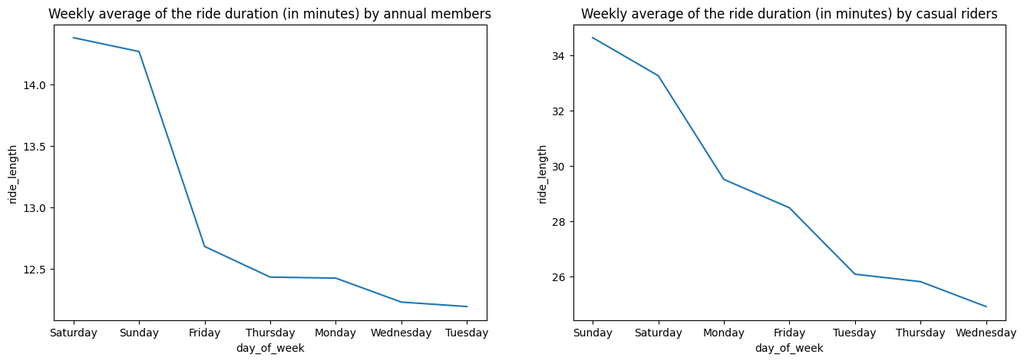

```python
# Using the same technique, but this time checking the ride_length:

			fig, axes = plt.subplots(nrows=1, ncols=2, figsize=(16, 5))

			df3 = df.loc[df['customer_type'] == 'member'] \
				.groupby( ['day_of_week'], as_index=False ) \
				.agg({'ride_id':'count', 'ride_length':'mean'}) \
				.sort_values('ride_length', ascending=False)

			sns.lineplot(ax=axes[0],
			x = df3['day_of_week'],
			y = df3['ride_length']) \
			.set(title = 'Weekly average of the ride duration (in minutes) by annual members')

			df4 = df.loc[df['customer_type'] == 'casual'] \
				.groupby( ['day_of_week'], as_index=False ) \
				.agg({'ride_id':'count', 'ride_length':'mean'}) \
				.sort_values('ride_length', ascending=False)

			sns.lineplot(ax=axes[1],
			x = df4['day_of_week'],
			y = df4['ride_length']) \
			.set(title = 'Weekly average of the ride duration (in minutes) by casual riders')
```

```python
df[df['customer_type'] == 'casual'].quantile(q=[0.75], axis=0, numeric_only=True)
```

|  | ride_length |
| --- | --- |
| 0.75 | 24.25 |

If we check the distribution of the weekly ride lengths, we should notice that they are not develop the same amount of usage in minutes than in the number of rides - it's quite the opposite tendency.

For the annual members the duration can be divided into two groups: duration for the weekdays and on the weekends, with an increased usage on the weekends. This means that **the distance is the same therefore the purpuse of the usage is the same depending on what days do they use the service**. However, they don't like riding on Sundays. If they do, they probably go to the same location as on Saturday (same ride length, different number of rides).

```python
# How does it look like for the whole 12 months?

			customer_by_period = df.groupby('period')['customer_type'].value_counts()

			customer_by_period
```

```
period   customer_type
			2022-03  member           190601
					 casual            88343
			2022-04  member           239853
					 casual           124080
			2022-05  member           347319
					 casual           275125
			2022-06  member           391891
					 casual           361929
			2022-07  member           408026
					 casual           397648
			2022-08  member           417206
					 casual           351164
			2022-09  member           395425
					 casual           290384
			2022-10  member           341370
					 casual           204205
			2022-11  member           231675
					 casual            98383
			2022-12  member           133285
					 casual            43746
			2023-01  member           145276
					 casual            38837
			2023-02  member           142626
					 casual            41818
			Name: customer_type, dtype: int64
```

```
[Text(0.5, 1.0, 'Monthly distribution of the number of rides by casual riders')]
```

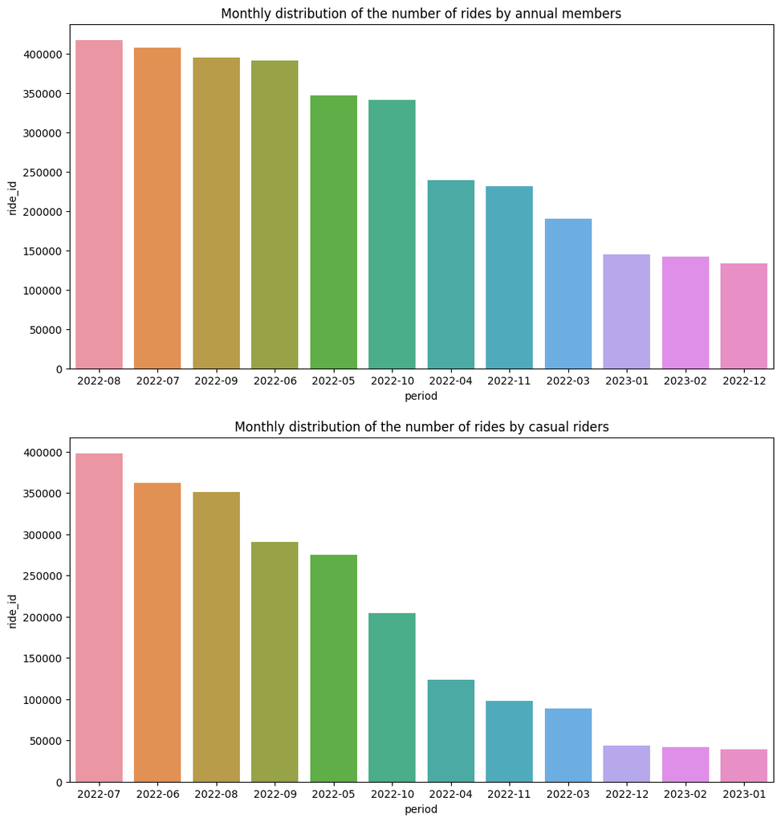

```python
# Creating subplot bar charts to visualize the number of rides for 12 months, sorted by the biggest usage:

			fig, axes = plt.subplots(nrows=2, ncols=1, figsize=(12, 13))

			df5 = df.loc[df['customer_type'] == 'member'] \
				.groupby(['period'], as_index=False) \
				.agg({'ride_id': 'count', 'ride_length': 'mean'}) \
				.sort_values('ride_id', ascending=False)

			sns.barplot(ax=axes[0],
			x = df5['period'],
			y = df5['ride_id']) \
			.set(title = 'Monthly distribution of the number of rides by annual members')

			df6 = df.loc[df['customer_type'] == 'casual'] \
				.groupby(['period'], as_index=False) \
				.agg({'ride_id': 'count', 'ride_length': 'mean'}) \
				.sort_values('ride_id', ascending=False)

			sns.barplot(ax=axes[1],
			x = df6['period'],
			y = df6['ride_id']) \
			.set(title = 'Monthly distribution of the number of rides by casual riders')
```

We can definitely identify some trends with a **strong correlation to the weather, since the willingness of riding a bike is strongly dependent of the good weather conditions.** The Cyclistic company is based in Chicago, where the climate is similar to the Hungarian weather: January is the coldest month and July is the warmest.

Therefore, as we could expect, Q2 and Q3 are the busiest season and P12 and P01 are the weakest. Casual riders have steeper decrease throughout the year which starts with a peak at the warmest month (P07) and ends in the coldest (P01). This is probably in relation with the tourists as they tend to visit Chicago in the warmer months.

However, we can see in the annual members' chart that the busiest season is from P05 to P10, which is increasing to the middle when the weather is the warmest. Then it decreases similarly by 3 months: [P04, P11, P03] and [P12, P02, P01]. I believe it's grouped because of the similar weather conditions.

This willingness can be vsualized the best with the number of rides sorted by the period.

```
[Text(0.5, 1.0, 'Monthly distribution of the number of rides by casual riders (sorted by period)')]
```

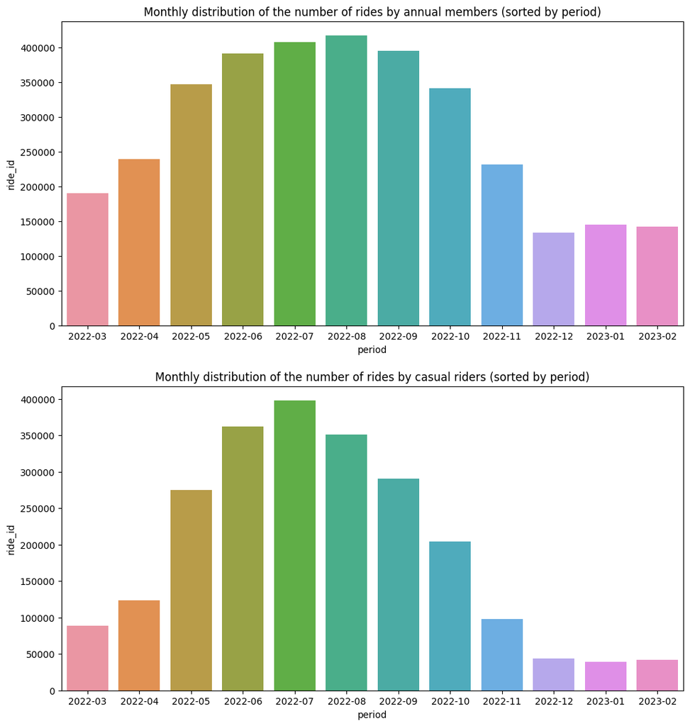

```python
fig, axes = plt.subplots(nrows=2, ncols=1, figsize=(12, 13))

			df7 = df.loc[df['customer_type'] == 'member'] \
				.groupby(['period'], as_index=False) \
				.agg({'ride_id': 'count', 'ride_length': 'mean'}) \
				.sort_values('period', ascending=True)

			sns.barplot(ax=axes[0],
			x = df7['period'],
			y = df7['ride_id']) \
			.set(title = 'Monthly distribution of the number of rides by annual members (sorted by period)')

			df8 = df.loc[df['customer_type'] == 'casual'] \
				.groupby(['period'], as_index=False) \
				.agg({'ride_id': 'count', 'ride_length': 'mean'}) \
				.sort_values('period', ascending=True)

			sns.barplot(ax=axes[1],
			x = df8['period'],
			y = df8['ride_id']) \
			.set(title = 'Monthly distribution of the number of rides by casual riders (sorted by period)')
```

We can see two beautiful normal distribution. This type of distribution is a continuous probability distribution in which most data points cluster toward the middle of the range (the mean), while the rest taper off symmetrically toward either extreme. So for example if we check the annual members we can see that P11 and P04 has similar number of rides, because they are similar in weather temperatures.

We can investigate further in the yearly tendencies by checking the duration of the rides. Let's sort the charts by period to check if we see the same trends as we saw on the weekly analysis.

```
[Text(0.5, 1.0, 'Monthly average of the ride duration by casual riders (in minutes)')]
```

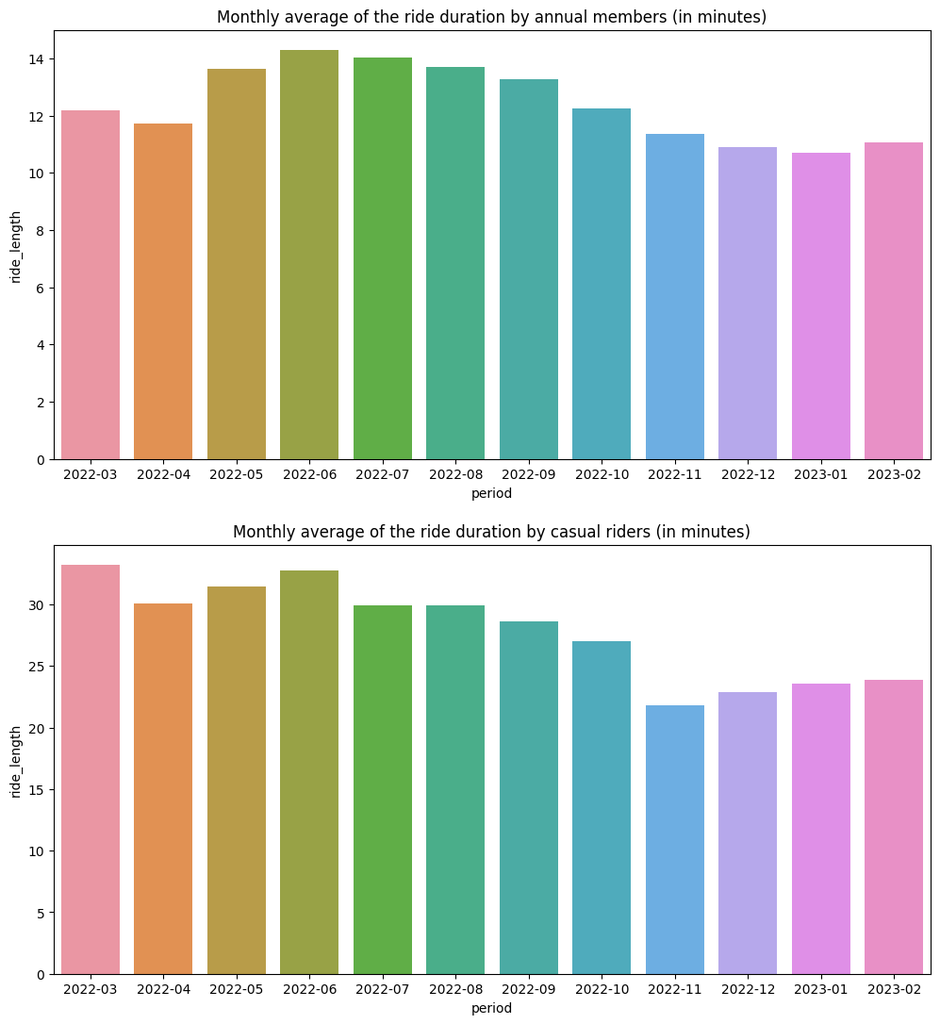

```python
fig, axes = plt.subplots(nrows=2, ncols=1, figsize=(12, 13))

			df9 = df.loc[df['customer_type'] == 'member'] \
				.groupby(['period'], as_index=False) \
				.agg({'ride_id': 'count', 'ride_length': 'mean'}) \
				.sort_values('period', ascending=True)

			sns.barplot(ax=axes[0],
			x = df9['period'],
			y = df9['ride_length']) \
			.set(title = 'Monthly average of the ride duration by annual members (in minutes)')

			df10 = df.loc[df['customer_type'] == 'casual'] \
				.groupby(['period'], as_index=False) \
				.agg({'ride_id': 'count', 'ride_length': 'mean'}) \
				.sort_values('period', ascending=True)

			sns.barplot(ax=axes[1],
			x = df10['period'],
			y = df10['ride_length']) \
			.set(title = 'Monthly average of the ride duration by casual riders (in minutes)')
```

I don't detect any significant change throughout the year for neither of customers regarding the lenght of the rides.

Since the annual members are probably using the service for the same purpose and since the weather is a key to the usage, I expected very low discripancy between the warmer months and the colder months (~3 minutes).

As from my experience, **the customers who are tend to ride bikes on the warmest days usually bear the coldest ones as well.** (Especially because Chicago's average temperature in the winter is -3°C, which we can considerate mild, while in the summer is 29°C). Although, we can see a light normal distribution here as well throughout the year because of the weather. They are more likely to ride longer routes in the warmer months.

Nevertheless, the casual riders have a bigger difference (~10 minutes).

We can see the same tendency here as in the weekly chart: **in the winter they tend to ride shorter routes (under 25 minutes)**. However, we don't see a normal distribution here as it's highly depending on the number of rides. This suggests that these riders are more impulsively using the service.

What is interesting is that **the casual riders have more than twice the ride length as the annual members**, which is probably because these riders are using the service for pleasure (f.e. site seeing).

Finally, we can check the bike types.

```python
# Counting the number of rides where the duration is more than 2 minutes:

			count_by_bike_type = (
				df
				.assign(ride_length_count=lambda df: df['ride_length'] <= 2)
				.groupby(['rideable_type'])['ride_length']
				.count()

			)

			count_by_bike_type
```

```
rideable_type
			classic_bike     2627504
			docked_bike       177546
			electric_bike    2895165
			Name: ride_length, dtype: int64
```

```python
# Counting the number of rides for each customer type by bike type:

			bike_type = df.groupby('customer_type')['rideable_type'].value_counts()
			bike_type
```

```
customer_type  rideable_type
			casual         electric_bike    1245263
						   classic_bike      892853
						   docked_bike       177546
			member         classic_bike     1734651
						   electric_bike    1649902
			Name: rideable_type, dtype: int64
```

```
[Text(0.5, 1.0, 'Distribution of the bike types by casual riders')]
```

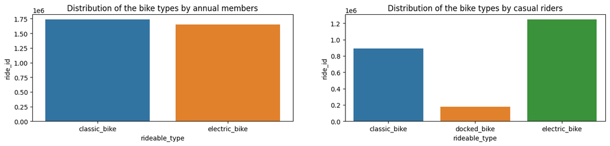

```python
# Visualize the usage of the bike types by customer

			fig, axes = plt.subplots(nrows=1, ncols=2, figsize=(16, 3))

			df11 = df.loc[df['customer_type'] == 'member'] \
				.groupby(['rideable_type'], as_index=False) \
				.agg({'ride_id':'count', 'ride_length':'mean'}) \
				.sort_values('rideable_type', ascending=True)

			sns.barplot(ax=axes[0],
			x = df11['rideable_type'],
			y = df11['ride_id']) \
			.set(title = 'Distribution of the bike types by annual members')

			df12 = df.loc[df['customer_type'] == 'casual'] \
				.groupby(['rideable_type'], as_index=False) \
				.agg({'ride_id': 'count', 'ride_length': 'mean'}) \
				.sort_values('rideable_type', ascending=True)

			sns.barplot(ax=axes[1],
			x = df12['rideable_type'],
			y = df12['ride_id']) \
			.set(title = 'Distribution of the bike types by casual riders')
```

Checking the number of rides per bike type, the annual members are using both electrical and classic ones, but they prefer the classic bikes.

Regarding the casual riders, the electric bike is the one that they used the most, while some choose the classic bikes. We can see that this type of customers are using the docked bikes as well, but they don't choose it that much.

What about the length of the rides?

```
[Text(0.5, 1.0, 'The average length of the rides per bike type by casual riders')]
```

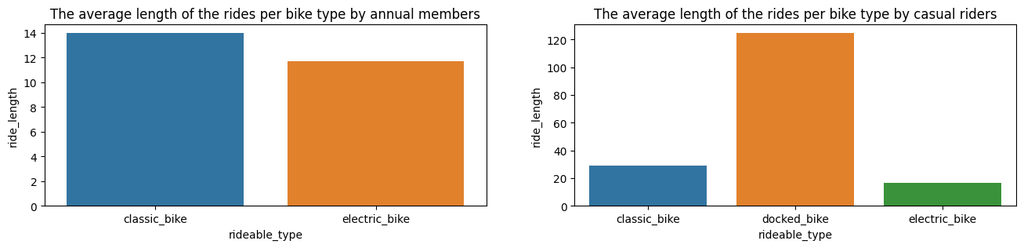

```python
# Checking the duration for each bike type per customer

			fig, axes = plt.subplots(nrows=1, ncols=2, figsize=(16, 3))

			df13 = df.loc[df['customer_type'] == 'member'] \
				.groupby(['rideable_type'], as_index=False) \
				.agg({'ride_id': 'count', 'ride_length': 'mean'}) \
				.sort_values('rideable_type', ascending=True)

			sns.barplot(ax=axes[0],
			x = df13['rideable_type'],
			y = df13['ride_length']) \
			.set(title = 'The average length of the rides per bike type by annual members')

			df14 = df.loc[df['customer_type'] == 'casual'] \
				.groupby(['rideable_type'], as_index=False) \
				.agg({'ride_id': 'count', 'ride_length': 'mean'}) \
				.sort_values('rideable_type', ascending=True)

			sns.barplot(ax=axes[1],
			x = df14['rideable_type'],
			y = df14['ride_length']) \
			.set(title = 'The average length of the rides per bike type by casual riders')
```

Since the annual member is most probably using the bikes for the same route, can be clearly deduced that the same route will be faster with an electric bike.

Logically, it can happen that the casual riders are faster with their routes using the electric bikes over the classic ones as well.

In spite of that, the all time high is ultimately the docked bikes regarding the rides' duration. The fact that these casual riders are not prefer these type of bikes, while it still has the longest rides makes me feel that this is an **impulsive action** to choose docked bikes over any other type of transportation. This is most likely a tourist characteristic: they see the many docking stations all over Chicago and they want to use it. Also, of course it can mean that the residents are using the services occasionally (f.e. other transportation failed, traffic jam, fun activity).

This impulsivity might be the most important information we could get from this dataset. It means we can affect these impulsive behaviour with simple marketing tactics.

## Summary

- Annual members using the service with more occasions on weekdays for the same amount of time. The duration is higher on weekends.

This means that the distance is the same therefore the purpuse of the usage is the same depending on what days do they use the service.

## Suggestion

#### 1. New passes for members based on current usage:

- Weekend passes from Friday to Sunday (72HR)
- Weekly passes (WP)
- Monthly passes (MP)
- Quarterly passes (QP)
- Half-year passes (HP)

#### 2. Pricing is better if bigger passes are chosen:

- **Single-ride is the worst deal**

Guide customers to use the service more.

- **Slightly better pricing with the Full-day pass** (Single x 1.3)

Better deal for the whole day.  
 (-> We can calculate the monthly price multiplying this with 30)

- **Best price for the 72HR** (Full day x 1.5)

Encourage casual riders to buy passes for the period they most likely riding.

- **Just slightly more expensive for WP** (72HR x 3)

Sounds a better deal then the weekend pass, but not too aggressive tactic.

- **More expensive for MP** (Full day x 28)

Intermediate option, not favorable.

- **QPs are better** (MP x 2)

Complementary 1 month if you choose bigger pass.

- **HPs are even better** (MP x 4)

Complementary 2 month if you choose bigger pass.

- **Annual passes are good** (MP x 9)

Complementary 3 month if you choose bigger pass.

#### 3. Get more insight

Complementary Single-ride pass if a questionnaire is filled out (answering sex, age, location, contact info).

This way we could further analyze the customer habits and define overall better strategies.

**Feedback, bug reports, and comments are not only welcome, but strongly encouraged!**